# Ottawa Temperature and Atmospheric Teleconnection Indices

An 85-year analysis of NAO, AO, PDO, and ENSO relationships with Ottawa (1940–2024)

Author

John Lewis - “Climate Analysis — Ottawa”

Published

May 26, 2026

# 1 Introduction

Large-scale patterns of ocean and atmospheric circulation — known as **teleconnection indices** — can modulate regional climate conditions thousands of kilometres away. For Ottawa, ON, a continental mid-latitude city with pronounced seasonal temperature swings, these remote forcings may contribute meaningfully to year-to-year and decade-to-decade variability on top of the long-term warming trend.

This report examines the statistical relationship between Ottawa’s surface air temperatures (1940–2024) and four major teleconnection indices:

- **NAO** — North Atlantic Oscillation: pressure seesaw between the Icelandic Low and Azores High
- **AO** — Arctic Oscillation: annular mode of polar vs. mid-latitude pressure-sometimes referred to as the Polar Vortex
- **PDO** — Pacific Decadal Oscillation: multi-decadal SST pattern in the North Pacific
- **ENSO** — El Niño–Southern Oscillation (via the Oceanic Niño Index): tropical Pacific SST anomalies

For each index, the analysis focuses on two temporal scales: **annual means** and **winter (December–January–February, DJF) seasonal means**, since winter is when teleconnection signals tend to be strongest at mid-latitudes.

# 2 Data

## 2.1 Data sources

| Variable | Source | Period | Resolution |
| --- | --- | --- | --- |
| Ottawa temperature | Environment Canada (OTTAWA MACDONALD-CARTIER INT’L A) | 1940–2024 | Daily |
| NAO | NOAA CPC (nao.monthly1.txt, extended 1940–1949) | 1940–2024 | Monthly |
| AO | NOAA CPC (`ao_y.f2.csv`) + `UsingR::arctic.oscillations` (1940–1949) | 1940–2024 | Monthly |
| PDO | NOAA CPC (`pdo1940.csv`) | 1940–2024 | Monthly |
| ONI (ENSO) | NOAA CPC (online, `oni.ascii.txt`) | 1950–2024 | 3-month running mean |

Temperature anomalies are computed as deviations from the 1940–2024 monthly climatological mean for each calendar month. Winter seasons span December–January–February (DJF), with December associated with the following calendar year (e.g., December 1999 belongs to Winter 2000).

# 3 Ottawa temperature overview

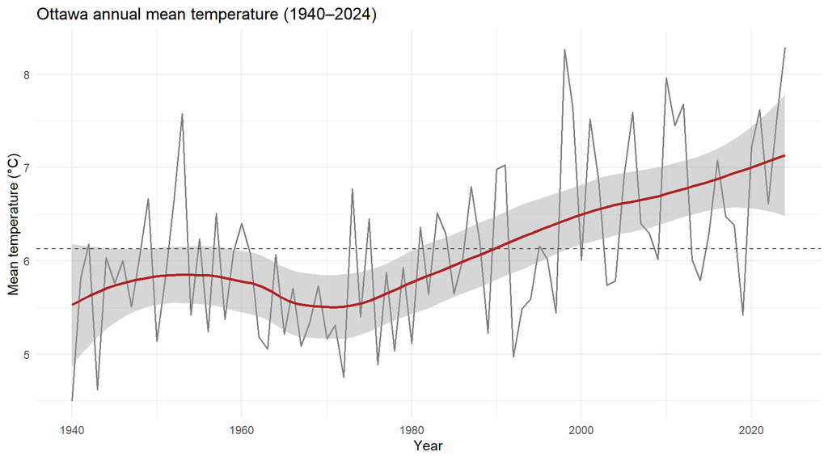

Figure 1: Annual mean temperature for Ottawa (1940–2024) with a LOESS smooth. The dashed line marks the long-term mean.

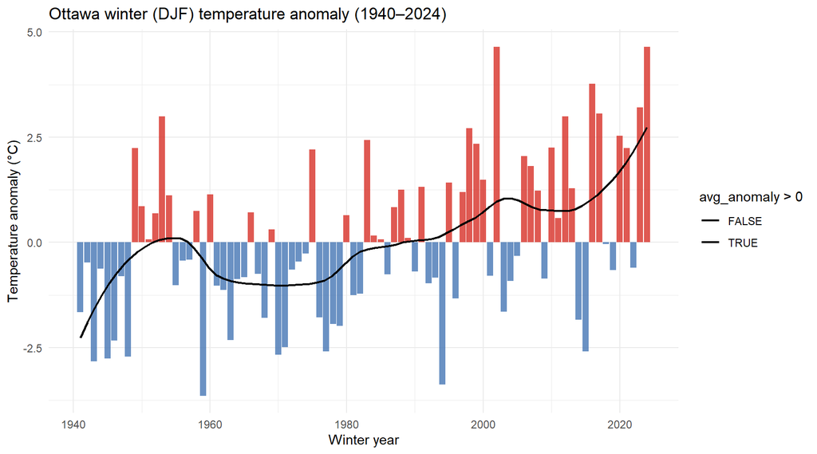

Figure 2: Ottawa winter (DJF) temperature anomaly relative to the 1940–2024 winter climatology. Red bars are warmer-than-average winters; blue bars are colder-than-average winters.

The LOESS curve reveals a clear upward trend in both annual and winter temperatures over the 85-year record, with the most pronounced warming occurring from the 1980s onward. Year-to-year variability in winter temperatures remains substantial, suggesting a role for large-scale atmospheric circulation patterns on top of the underlying warming trend.

# 4 North Atlantic Oscillation (NAO)

## 4.1 What is the NAO?

The NAO is defined by the pressure difference between the Icelandic Low and the Azores High. A **positive NAO** drives stronger westerlies, bringing mild, wet conditions to northwestern Europe and typically milder winters to eastern North America. A **negative NAO** allows cold Arctic air to penetrate further south, producing colder winters in eastern Canada and the northeastern United States.

## 4.2 NAO index over time

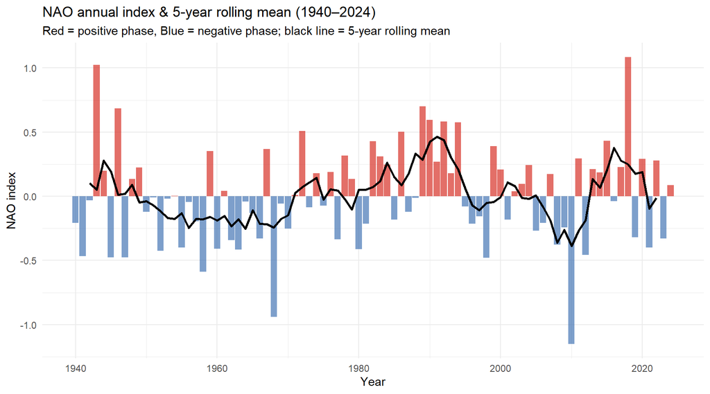

Figure 3: Annual mean NAO index (1940–2024) with 5-year rolling mean.

## 4.3 NAO vs. Ottawa winter temperature

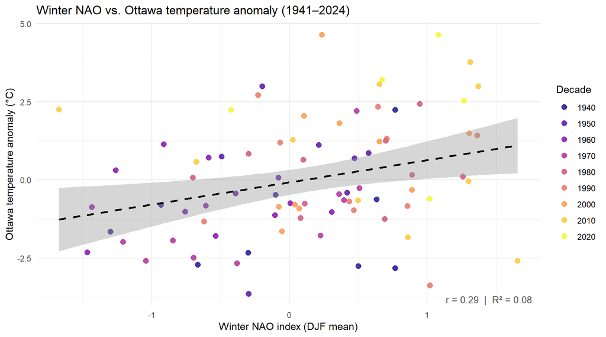

Figure 4: Scatter plot of winter (DJF) NAO index vs. Ottawa winter temperature anomaly. Colour indicates decade.

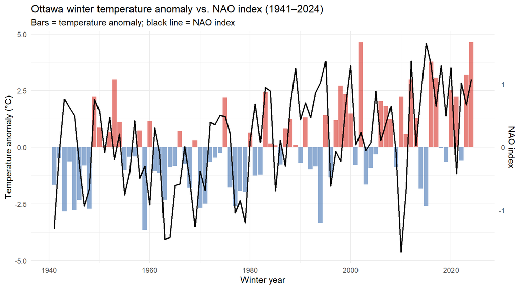

Figure 5: Winter Ottawa temperature anomaly (bars) and NAO index (line), scaled to a common axis.

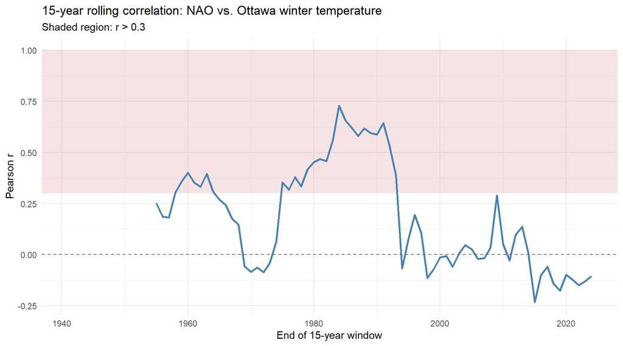

Figure 6: 15-year rolling Pearson correlation between winter NAO and Ottawa winter temperature anomaly. The shaded band marks r > 0.3.

The NAO shows a modest positive correlation with Ottawa winter temperatures (r ≈ 0.29), accounting for roughly 8% of winter temperature variance. The rolling correlation reveals that this relationship has not been stable over time — there are multi-decadal periods of stronger and weaker coupling.

# 5 Arctic Oscillation (AO)

## 5.1 What is the AO?

The AO is the leading mode of sea-level pressure variability in the Northern Hemisphere extratropics. It is closely related to the NAO but captures a more annular (wave or ring-like) structure around the Arctic. A **positive AO** strengthens the polar vortex and keeps cold Arctic air bottled up at high latitudes, favouring mild winters in mid-latitude cities like Ottawa. A **negative AO** weakens the polar vortex and allows cold outbreaks to surge equatorward.

## 5.2 AO index over time

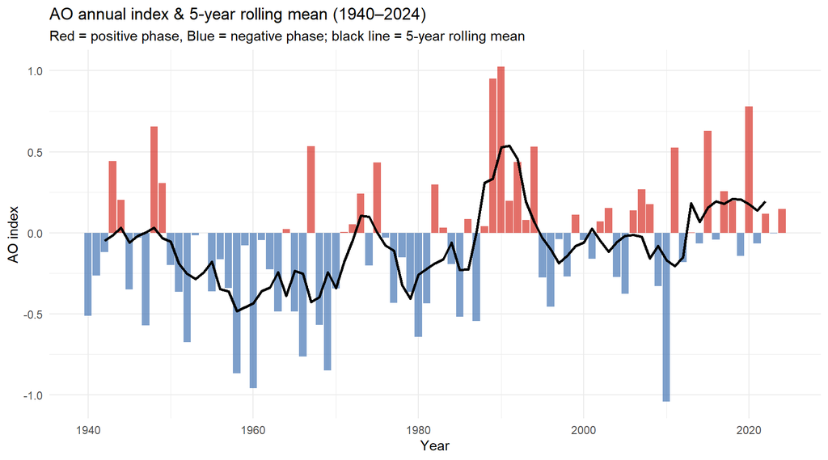

Figure 7: Annual mean AO index (1940–2024) with 5-year rolling mean.

## 5.3 AO vs. Ottawa winter temperature

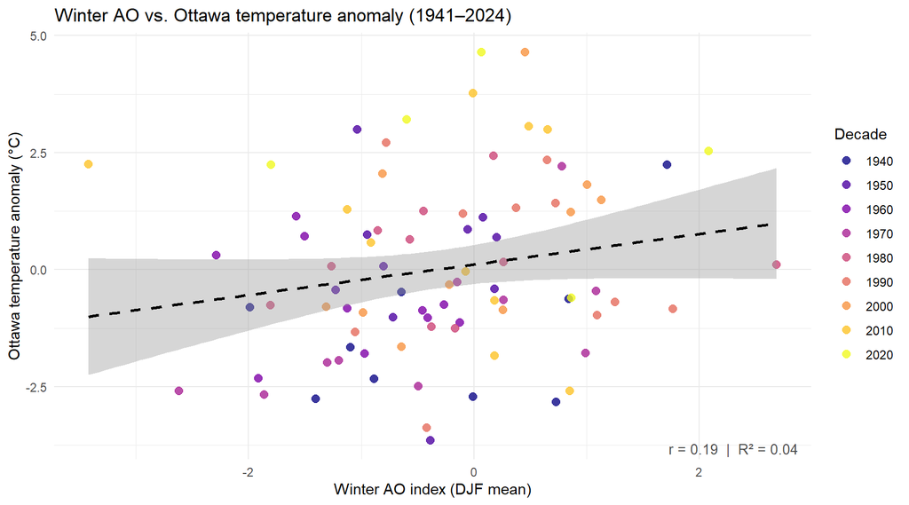

Figure 8: Scatter plot of winter (DJF) AO index vs. Ottawa winter temperature anomaly.

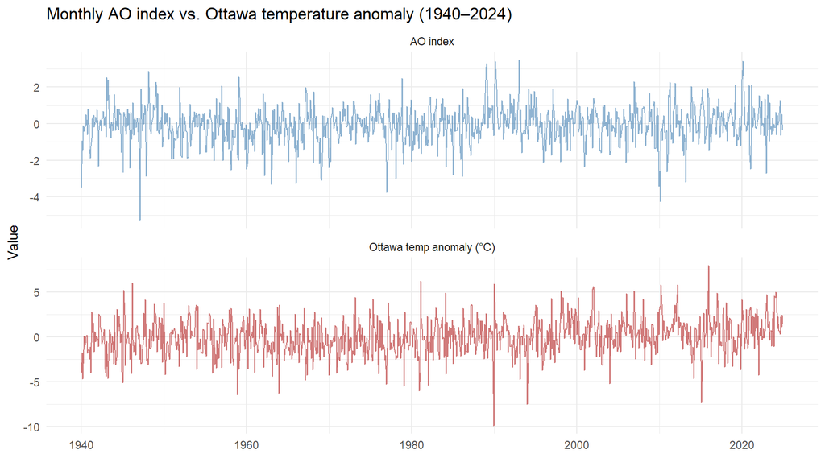

Figure 9: Monthly AO index and Ottawa temperature anomaly time series (1940–2024), shown on separate panels for visual comparison.

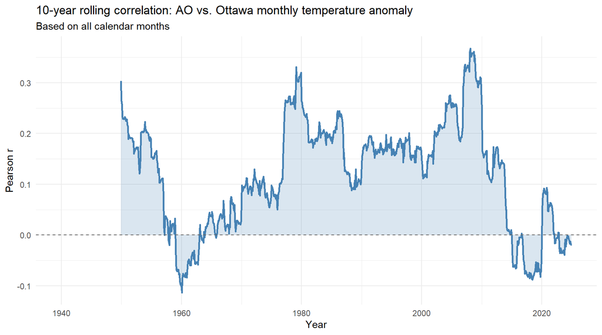

Figure 10: 10-year rolling Pearson correlation between monthly AO and Ottawa temperature anomaly (1940–2024).

The AO shows a positive correlation with Ottawa winter temperatures (r ≈ 0.19), explaining roughly 4% of winter temperature variance. The rolling correlation on monthly data reveals periods of stronger and weaker coupling, reflecting the non-stationary nature of AO’s influence at this location.

# 6 Pacific Decadal Oscillation (PDO)

## 6.1 What is the PDO?

The PDO is a pattern of sea surface temperature variability in the North Pacific Ocean that oscillates on multi-decadal timescales (roughly 20–30 years per phase). Unlike ENSO, which operates on interannual timescales, the PDO represents longer-term “regime shifts.” A **positive PDO** (warm North Pacific coast, cool central Pacific) is associated with warmer-than-average winters across much of North America; a **negative PDO** tends to be associated with cooler conditions. The PDO may amplify or suppress ENSO teleconnections.

## 6.2 PDO regime over time

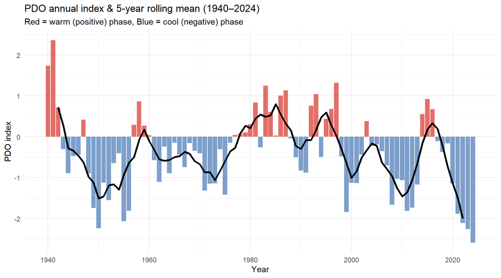

Figure 11: Annual mean PDO index (1940–2024) with 5-year rolling mean. Positive (warm) phases are shown in red, negative (cool) phases in blue.

## 6.3 PDO vs. Ottawa winter temperature

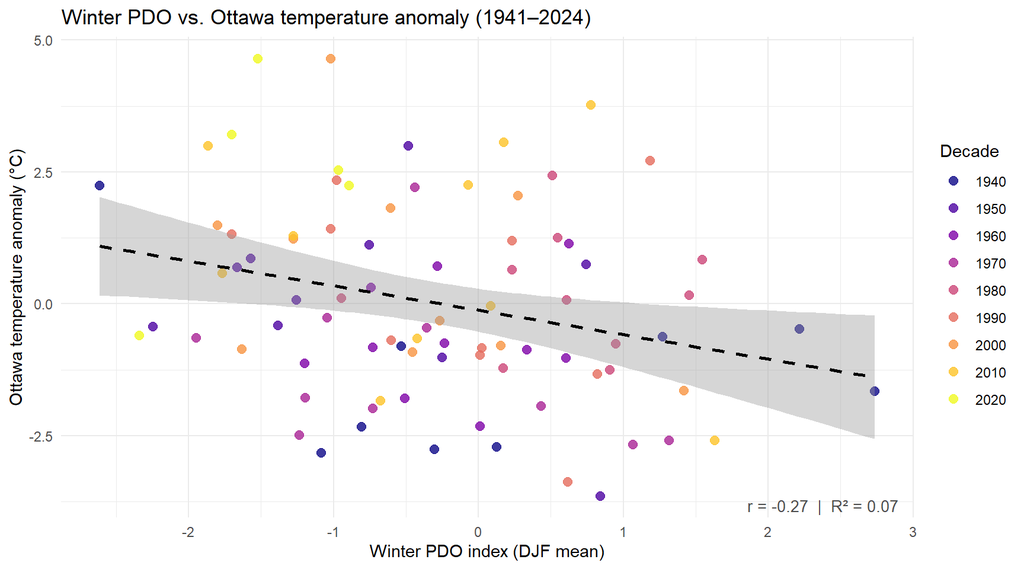

Figure 12: Scatter plot of winter (DJF) PDO index vs. Ottawa winter temperature anomaly.

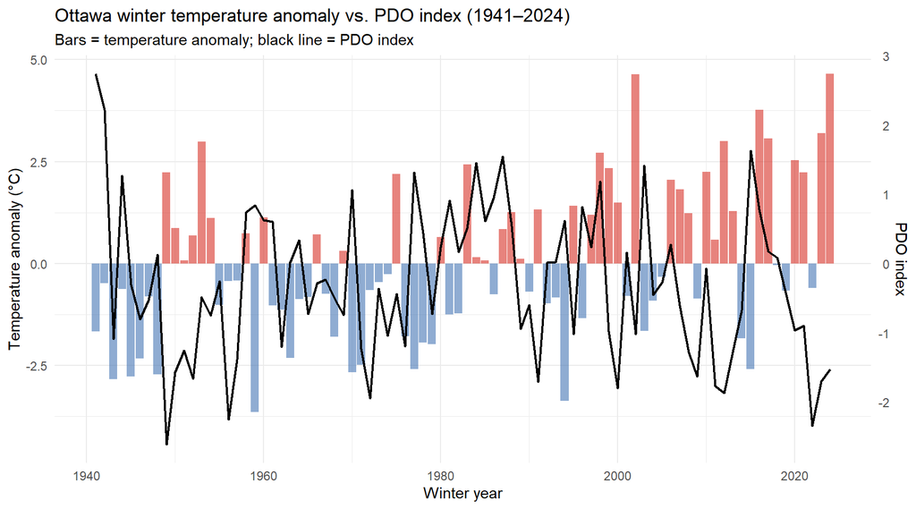

Figure 13: Ottawa winter temperature anomaly (bars) and PDO index (line), scaled to a common axis.

# 7 El Niño–Southern Oscillation (ENSO)

## 7.1 What is ENSO?

ENSO is the dominant mode of interannual climate variability on Earth, originating in the tropical Pacific. **El Niño** events (warm phase, ONI ≥ +0.5°C) and **La Niña** events (cool phase, ONI ≤ −0.5°C) teleconnect to mid-latitudes by altering jet stream positioning and stormtrack patterns. For eastern Canada, El Niño winters tend to be milder than average and La Niña winters tend to be cooler. The ONI (Oceanic Niño Index) is the 3-month running mean of SST anomalies in the Niño-3.4 region; data are available from NOAA from 1950 onward.

## 7.2 ONI index over time

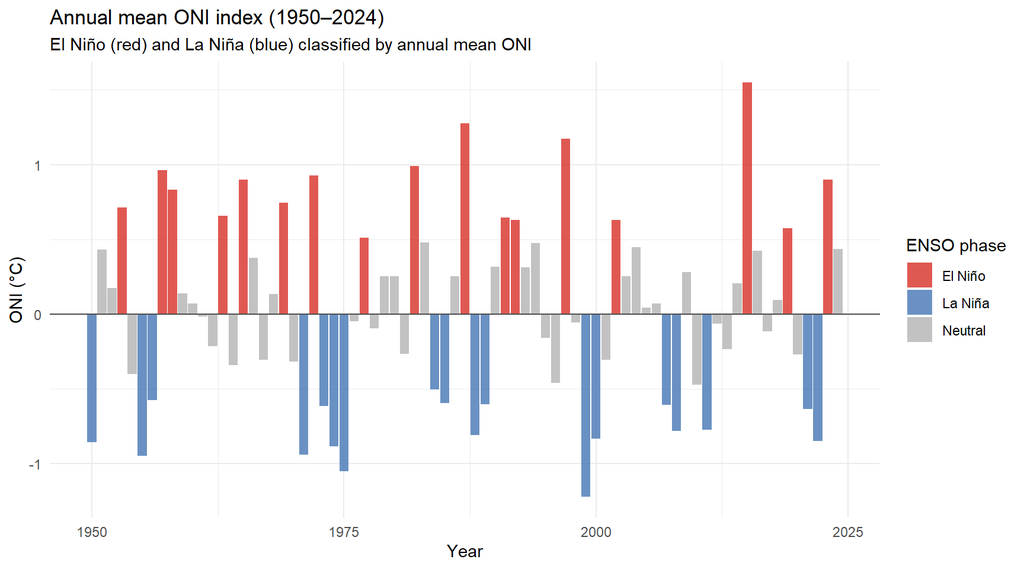

Figure 14: Annual mean ONI (Oceanic Niño Index) for 1950–2024. Red bars indicate El Niño years (annual mean ≥ +0.5°C); blue bars indicate La Niña years (≤ −0.5°C).

## 7.3 Ottawa winter temperature by ENSO phase

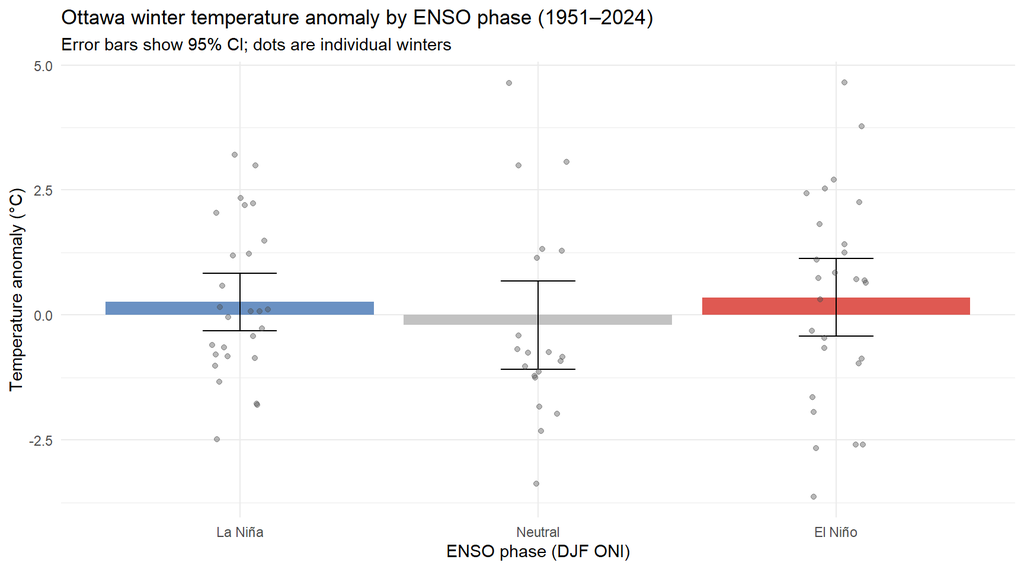

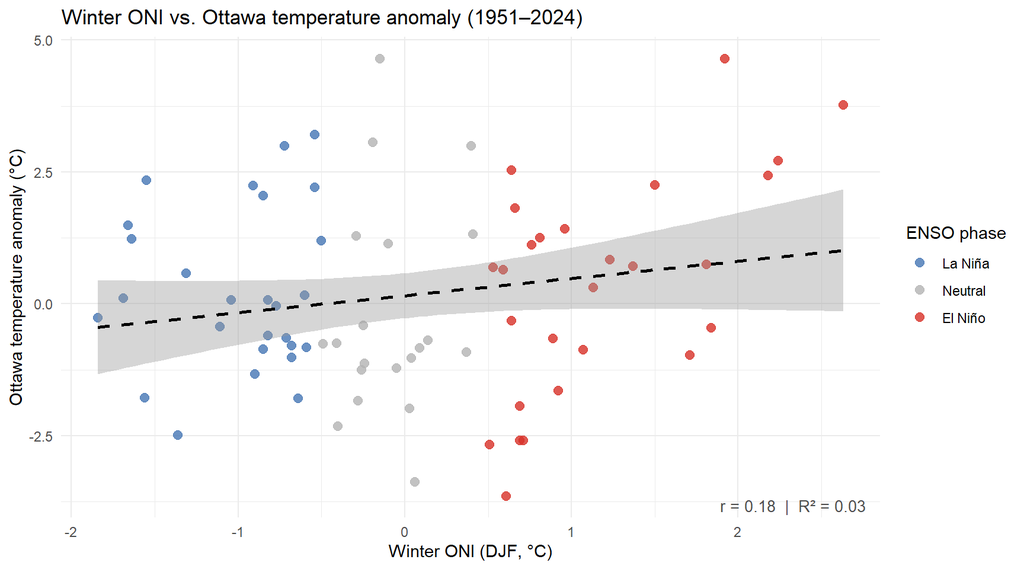

Figure 16: Winter ONI (DJF) vs. Ottawa winter temperature anomaly (1951–2024).

# 8 Multi-index comparison

## 8.1 Summary of correlations

Table 1: Pearson correlation and variance explained (R²) between each index and Ottawa winter temperature anomaly. Note: ENSO covers 1951–2024; all others cover 1941–2024.

| Index | Period | r | R² (%) |
| --- | --- | --- | --- |
| NAO | 1941–2024 | 0.289 | 8.4 |
| AO | 1941–2024 | 0.187 | 3.5 |
| PDO | 1941–2024 | -0.270 | 7.3 |
| ENSO (ONI) | 1951–2024 | 0.181 | 3.3 |

## 8.2 Side-by-side winter scatter panels

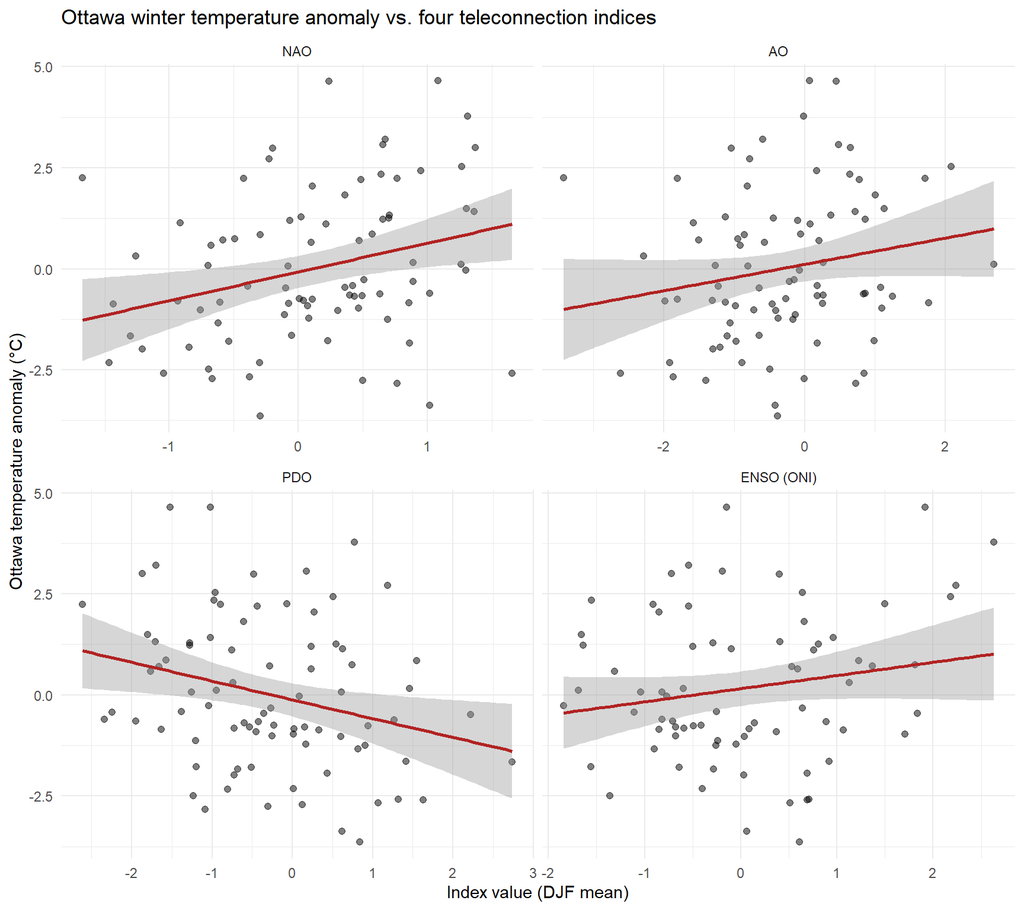

Figure 17: Winter temperature anomaly vs. each of the four indices (panels). Each panel shows the linear fit and its 95% confidence interval.

## 8.3 Winter Cross Correlation

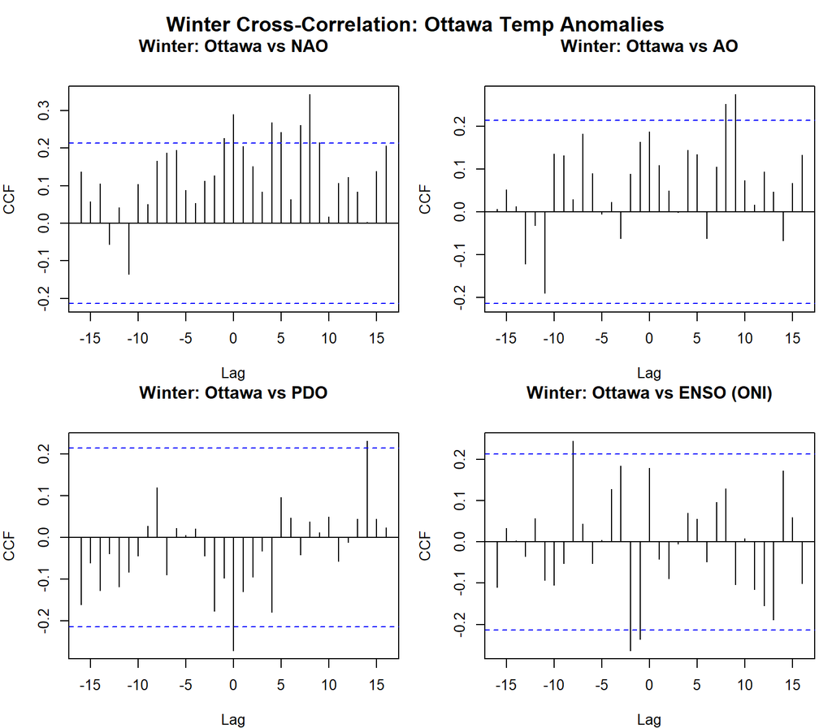

If ccf(temp, index), has a significant spike at a negative lag, this indicates that the atmospheric index leads the Ottawa temperature. A spike at zero indicates simultaneous co-variation.

Notice that some of those indices (especially the NAO and AO) show very similar lag patterns. This occurs often because they are physically coupled by essentially different ways of measuring the same broad atmospheric pressure variations. There is a significant correlation value at lag 0 for NAO teleconnection as was noted previously. the NAO or AO correlations are much stronger (taller bars) in the winter version. This is because the jet stream is more active and “coupled” with the surface temperature in Ottawa during the colder months, whereas in the summer, local heating often drowns out those big teleconnection signals. Another observation of this data is the significant negative correlation at lag 0 for the PDO, where as with ENSO a negative correlation at lag 1 and 2 for previous winters, means that as the index goes up, Ottawa’s temperature goes down. This is common with ENSO in certain regions of Canada where the “seesaw” effect (teleconnections) can flip depending on the strength of the Pacific Jet Stream.

Reminder: In a winter-only dataset, Lag 1 is still 1 year (the previous winter). If the data are strictly sequential winters (1941, 1942, etc.), ccf will show how last year’s index correlates with this year’s temperature anomaly.

## 8.4 Annual anomaly co-variation

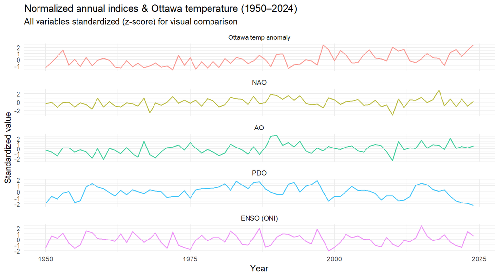

Figure 18: Annual mean values of each teleconnection index and Ottawa temperature anomaly (1950–2024), all normalized to zero mean and unit standard deviation to enable visual comparison.

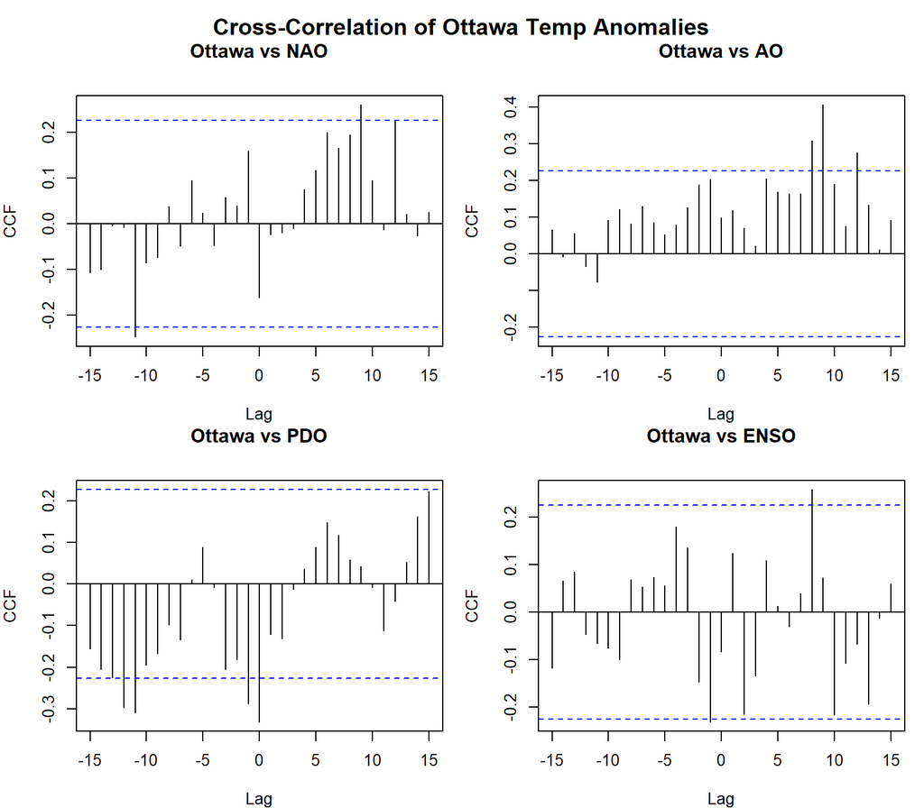

## 8.5 Highlights of the Annual Cross Correlation

The Atlantic “Lull” (NAO & AO):

The 8-9 Year Peak: Since Ottawa is inland, the direct “year-to-year” impact of the North Atlantic Oscillation is often messier than it is on the coast. That 8-9 year signal is a classic signature of decadal variability. It suggests that while the NAO doesn’t dictate if next year will be hot or cold, there is a decadal “rhythm” where the Atlantic pressure systems sync up with Ontario/Quebec temperatures over longer cycles.

# 9 Discussion and conclusions

The lag relationship between Ottawa temperature anomalies, for both annual and winter periods, and the four different indices indicate that there are specific phase date relationships that are statistically significant.

*Data sources: Environment Canada (Ottawa temperature); NOAA Climate Prediction Center (NAO, AO, PDO, ONI); `UsingR` R package (historical AO, 1940–1949).*

Disclosure: Posit AI Assistant help enhance my R code on some of the graphs and produced the code for two new plots. It, also, provided suggestions to help make a more readable text. Gemini provided the R code for calculating the cross correlation plots.